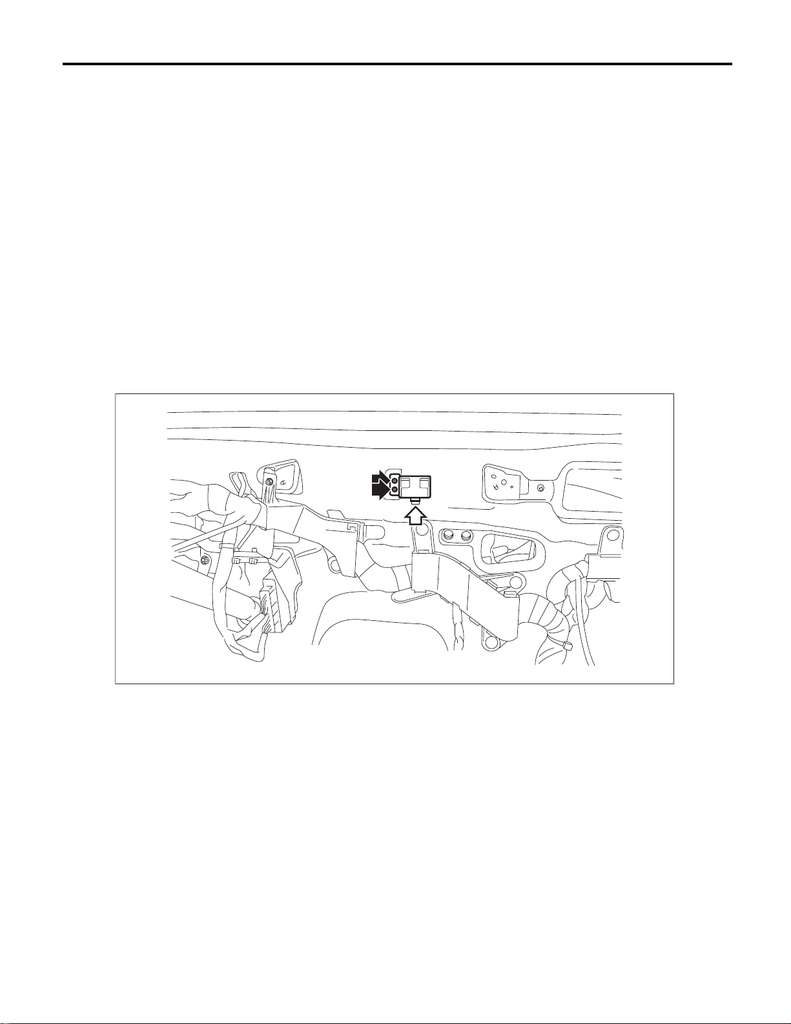

SL-72

Security Control Module

SECURITY AND LOCKS

20.Security Control Module

A: REMOVAL

CAUTION:

• Before handling the airbag module, refer to “CAUTION” of “General Description” in “AIRBAG SYS-

TEM”. <Ref. to AB-9, CAUTION, General Description.>

• Do not allow harness and connectors to interfere or get tangled up with other parts.

• If the steering wheel and steering angle sensor (steering roll connector) are removed, perform

“VDC sensor midpoint setting mode” of the VDC. <Ref. to VDC-16, VDC SENSOR MIDPOINT SETTING

MODE, ADJUSTMENT, VDC Control Module and Hydraulic Control Unit (VDCCM&H/U).>

1) Disconnect the ground cable from battery and wait for at least 60 seconds before starting work. <Ref. to

NT-5, BATTERY, NOTE, Note.>

NOTE:

For models other than STI model, disconnect the ground terminal from battery sensor.

2) Remove the instrument panel assembly. <Ref. to EI-69, REMOVAL, Instrument Panel Assembly.>

3) Remove the heater and cooling unit assembly. <Ref. to AC-54, REMOVAL, Heater and Cooling Unit.>

4) Remove the security control module.

(1) Disconnect the connector.

(2) Remove the nuts, and remove the security control module.

SL-01529

[figure not shown]

SL-73

Security Control Module

SECURITY AND LOCKS

B: INSTALLATION

CAUTION:

• Before handling the airbag module, refer to “CAUTION” of “General Description” in “AIRBAG SYS-

TEM”. <Ref. to AB-9, CAUTION, General Description.>

• Do not allow harness and connectors to interfere or get tangled up with other parts.

• If the steering wheel and steering angle sensor (steering roll connector) are removed, perform

“VDC sensor midpoint setting mode” of the VDC. <Ref. to VDC-16, VDC SENSOR MIDPOINT SETTING

MODE, ADJUSTMENT, VDC Control Module and Hydraulic Control Unit (VDCCM&H/U).>

1) Install the security control module.

Tightening torque:

7.5 N·m (0.8 kgf-m, 5.5 ft-lb)

2) Install the heater and cooling unit assembly. <Ref. to AC-56, INSTALLATION, Heater and Cooling Unit.>

3) Install the instrument panel assembly. <Ref. to EI-77, INSTALLATION, Instrument Panel Assembly.>

4) Connect the battery ground terminal. <Ref. to NT-5, BATTERY, NOTE, Note.>

NOTE:

For models other than STI model, connect the ground terminal to battery sensor.